**Advancement Report: September 2022**

## Donor Giving Revenue Summary

### BRIEFING - Advancement Committee

Donor Giving

FY 2022 to 2023 New Budget

Total Gifts in current FY July’22 - August’23

Individual

$1,136,420

$76,460.54

Corporate

$94,000

Sub-Total

$1,230,420

$76,460.54

Transformational Gifts

Total

$1,230,420

$76,460.54

### **Composition of Gifts**

*by Donor type*

*by Gift type*

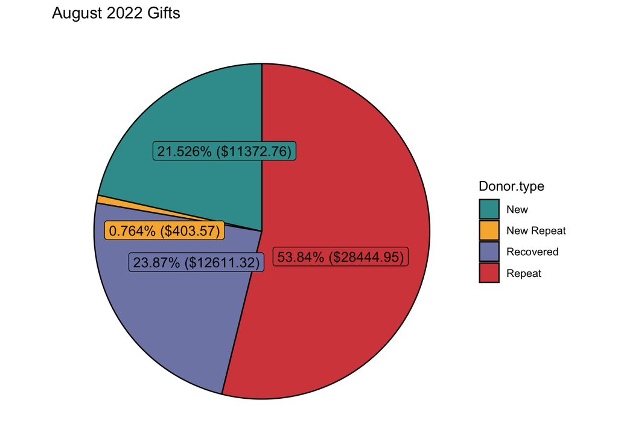

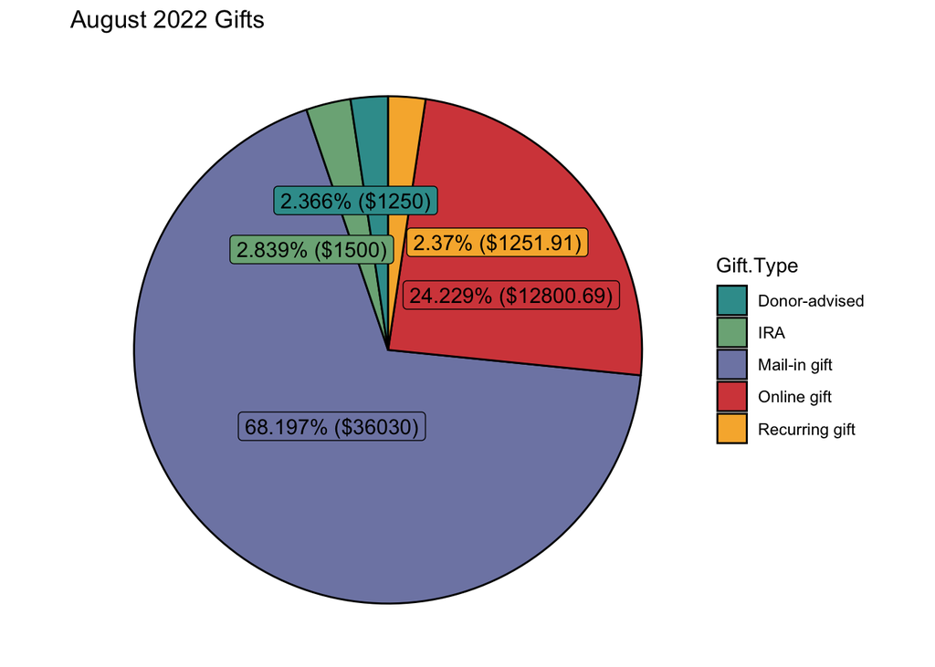

### **New Fiscal Year, 2022- 2023**

Major Gift details: 2022 July-August 31 Gifts and Pledges of $10,000 or greater, excluding board members, include two gifts totaling $20,265.88: Peter Kellner at $10,265.88 (new first-time donor), and Joan and James Shapiro Foundation at $10,000.00 (Joan is a former Governing Board member, last gift in 2021 at $1,000).

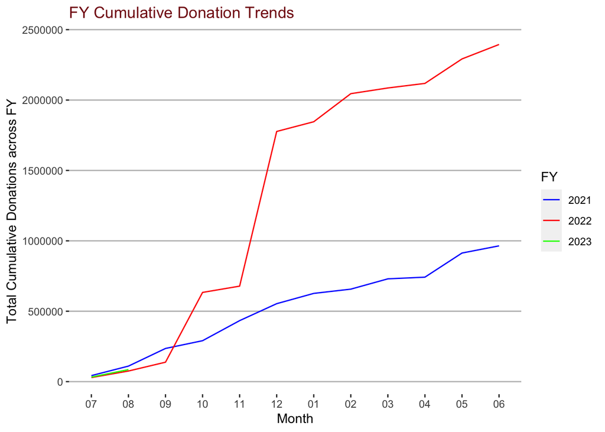

### **Conversations Before Midnight**

We are currently Fundraising for the November 9th, 2022 “Conversations Before Midnight”, the Bulletin’s annual virtual gathering. This event is budgeted at $189,000. The invitations dropped mid-September and the online reservation portal is now open. Past table buyers and Governing Board members have received the event sponsorship packet. Solicitations for event support are ongoing. The sponsorship packet is included in your board meeting book. We are grateful to Governing Board members who have already their made reservations and to Dave Kuhlman for bringing in the event’s lead sponsor, Axiom Consulting Partners.